# R für Einsteiger: Musterlösungen

Kapitel 13: Varianzanalyse ohne Messwiederholung

*Diese Musterlösung wurde erstellt von Peter Hähner (Ruhr-Universität Bochum).*

*(c) Luhmann: R fÃ¼r Einsteiger, 5. Aufl., Beltz, 2020*

## Vorbereitungen

Setzen Sie ein Arbeitsverzeichnis oder legen Sie ein entsprechendes R-Projekt an (Kap. 23).

Laden Sie dann die Datei `erstis.RData`.

```r
load("erstis.RData")
```

Laden Sie die benötigten Pakete (ggf. müssen Sie diese vorab noch installieren).

```r
library(psych)
library(afex)
library(tidyverse)
library(emmeans)
library(car)
```

## Aufgabe 1

Unterscheiden sich die vier Kurse (Variable `gruppe`) in ihrer Prokrastination (Variable `prok`)? Berechnen Sie auch deskriptive Statistiken, die Stichprobengröße sowie die Effektstärke Î·<sup>2</sup>. Führen Sie geeignete Post-hoc-Tests durch.

```r
# Deskriptive Statistiken und StichprobengrÃ¶Ãe
describeBy(erstis$prok, erstis$gruppe, mat = TRUE)
```

```
##     item group1 vars  n     mean        sd median  trimmed     mad min max
## X11    1 Kurs 1    1 46 2.421739 0.5419771    2.4 2.434211 0.74130 1.3 3.3
## X12    2 Kurs 2    1 49 2.459184 0.5869832    2.5 2.463415 0.59304 1.1 3.7
## X13    3 Kurs 3    1 35 2.494286 0.6024181    2.5 2.506897 0.44478 1.0 3.6
## X14    4 Kurs 4    1 46 2.467391 0.5304314    2.5 2.476316 0.51891 1.3 3.6
##     range       skew   kurtosis         se
## X11   2.0 -0.1098610 -1.0657944 0.07991016
## X12   2.6 -0.1642345 -0.6381243 0.08385475
## X13   2.6 -0.2172660 -0.2292875 0.10182724
## X14   2.3 -0.1396663 -0.4868258 0.07820785
```

```r
# ANOVA
anova.1 <- aov_car(prok ~ gruppe + Error(code), data = erstis)
```

```
## Contrasts set to contr.sum for the following variables: gruppe
```

```r
anova.1
```

```
## Anova Table (Type 3 tests)
##
## Response: prok
##   Effect     df  MSE    F  ges p.value
## 1 gruppe 3, 172 0.32 0.12 .002    .951
## ---
## Signif. codes:  0 '***' 0.001 '**' 0.01 '*' 0.05 '+' 0.1 ' ' 1
```

Die vier Gruppen unterscheiden sich nicht in ihrer Prokrastination (*F*(3, 172) = 0.12, *p* = .951, Î·<sup>2</sup> < .01). Post-Hoc-Tests wären in der Praxis daher nicht erforderlich, sie wurden nur aufgrund der Aufgabenstellung durchgeführt.

```r
ph.1 <- emmeans(anova.1, specs = "gruppe")
pairs(ph.1)
```

```
##  contrast        estimate    SE  df t.ratio p.value
##  Kurs 1 - Kurs 2 -0.03744 0.116 172 -0.323  0.9883
##  Kurs 1 - Kurs 3 -0.07255 0.127 172 -0.573  0.9399
##  Kurs 1 - Kurs 4 -0.04565 0.118 172 -0.388  0.9801
##  Kurs 2 - Kurs 3 -0.03510 0.125 172 -0.281  0.9922
##  Kurs 2 - Kurs 4 -0.00821 0.116 172 -0.071  0.9999
##  Kurs 3 - Kurs 4  0.02689 0.127 172  0.213  0.9966
##
## P value adjustment: tukey method for comparing a family of 4 estimates
```

## Aufgabe 2

Für Erstis werden jedes Jahr eine Reihe von Veranstaltungen angeboten, die den Einstieg ins Studium erleichtern sollen. Überprüfen Sie, ob der Besuch der Studienberatung (`uni1`) und die Teilnahme an der Orientierungswoche (`uni3`) einen Effekt auf die Zufriedenheit mit den Studienbedingungen (`zuf.bed.1`) haben. Berechnen Sie auch die üblichen deskriptiven Statistiken für die vier Gruppen und stellen die Ergebnisse grafisch dar. Führen Sie geeignete Post-Hoc-Tests durch.

```r
# Deskriptive Statistiken und StichprobengrÃ¶Ãe
describeBy(erstis$zuf.bed.1, list(erstis$uni1, erstis$uni3), mat = TRUE)
```

```
##     item group1 group2 vars  n     mean        sd   median  trimmed    mad
## X11    1   nein   nein    1 30 2.522222 0.7201710 2.666667 2.527778 0.4942
## X12    2     ja   nein    1 16 2.458333 0.8333333 2.666667 2.476190 0.9884
## X13    3   nein     ja    1 65 3.015385 0.5934561 3.000000 3.056604 0.4942
## X14    4     ja     ja    1 49 2.557823 0.8371793 2.666667 2.552846 0.9884
##          min      max    range        skew   kurtosis         se
## X11 1.000000 4.000000 3.000000 -0.14735669 -0.5856488 0.13148463
## X12 1.000000 3.666667 2.666667 -0.20925000 -1.2735187 0.20833333
## X13 1.333333 4.000000 2.666667 -0.68998626  0.3551793 0.07360917
## X14 1.000000 4.000000 3.000000  0.07768176 -1.1101619 0.11959705
```

```r
# ANOVA
anova.2 <- aov_car(zuf.bed.1 ~ uni1 * uni3 + Error(code),
                   data = erstis)
```

```
## Contrasts set to contr.sum for the following variables: uni1, uni3
```

```r
anova.2
```

```
## Anova Table (Type 3 tests)
##
## Response: zuf.bed.1
##      Effect     df  MSE      F  ges p.value
## 1      uni1 1, 156 0.52 3.95 * .025    .049
## 2      uni3 1, 156 0.52 5.10 * .032    .025
## 3 uni1:uni3 1, 156 0.52   2.25 .014    .136
## ---
## Signif. codes:  0 '***' 0.001 '**' 0.01 '*' 0.05 '+' 0.1 ' ' 1
```

```r
# Post-Hoc-Tests 1: alle Paarvergleiche
ph.2 <- emmeans(anova.2, specs = ~ uni1 * uni3)
pairs(ph.2)
```

```
##  contrast            estimate    SE  df t.ratio p.value
##  nein,nein - ja,nein   0.0639 0.224 156  0.285  0.9919
##  nein,nein - nein,ja  -0.4932 0.160 156 -3.089  0.0126
##  nein,nein - ja,ja    -0.0356 0.168 156 -0.212  0.9966
##  ja,nein - nein,ja    -0.5571 0.202 156 -2.759  0.0326
##  ja,nein - ja,ja      -0.0995 0.208 156 -0.478  0.9639
##  nein,ja - ja,ja       0.4576 0.137 156  3.343  0.0057
##
## P value adjustment: tukey method for comparing a family of 4 estimates
```

```r
# Post-Hoc-Tests 2: bedingte Mittelwertsdifferenzen
ph.3 <- emmeans(anova.2, specs = ~uni1 | uni3)
pairs(ph.3)
```

```
## uni3 = nein:
##  contrast  estimate    SE  df t.ratio p.value
##  nein - ja   0.0639 0.224 156 0.285   0.7758
##
## uni3 = ja:
##  contrast  estimate    SE  df t.ratio p.value
##  nein - ja   0.4576 0.137 156 3.343   0.0010
```

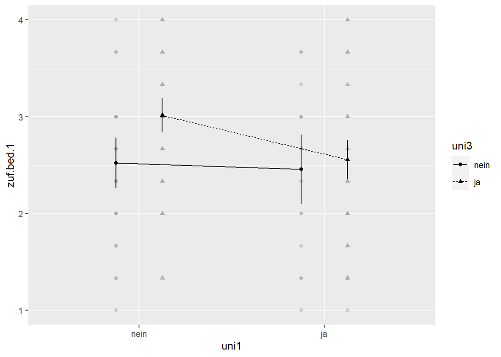

```r
# Graphische Ergebnisdarstellung
afex_plot(anova.2, x = "uni1", trace = "uni3")
```